# Assignment_5_2.md

Student Name:Koki Sasagawa  
Student ID:999054646

Insert answers to R SNP exercises 1 - 4 here. Submit .Rmd and .html by git.

```r
library(ggplot2)
vcf.data <- read.table("/home/ubuntu/Assignments/Assignment_5_Sasagawa.Koki/SNP_analysis/IMB211_R500.vcf",as.is=T,na.strings = ".")
head(vcf.data)
```

```
##    V1   V2 V3 V4 V5          V6 V7
## 1 A01 2872 NA  C  G 7.95912e-04 NA
## 2 A01 2915 NA  C  T 1.74689e-01 NA
## 3 A01 2938 NA  T  C 7.98584e-04 NA
## 4 A01 2950 NA  T  A 1.28998e+01 NA
## 5 A01 4862 NA  G  T 1.76271e+03 NA
## 6 A01 5070 NA  G  A 1.53156e+03 NA
##                                                                                                                                                                                                                                                                                                          …
## 1                        AB=0;ABP=0;AC=4;AF=1;AN=4;AO=6;CIGAR=1X;DP=6;DPB=6;DPRA=0;EPP=16.0391;EPPR=0;GTI=0;LEN=1;MEANALT=1;MQM=3;MQMR=0;NS=2;NUMALT=1;ODDS=8.61212;PAIRED=0;PAIREDR=0;PAO=0;PQA=0;PQR=0;PRO=0;QA=196;QR=0;RO=0;RPL=0;RPP=16.0391;RPPR=0;RPR=6;RUN=1;SAF=0;SAP=16.0391;SAR=6;SRF=0;SRP=0;…
## 2                        AB=0;ABP=0;AC=4;AF=1;AN=4;AO=6;CIGAR=1X;DP=6;DPB=6;DPRA=0;EPP=4.45795;EPPR=0;GTI=0;LEN=1;MEANALT=1;MQM=3;MQMR=0;NS=2;NUMALT=1;ODDS=3.19335;PAIRED=0;PAIREDR=0;PAO=0;PQA=0;PQR=0;PRO=0;QA=223;QR=0;RO=0;RPL=4;RPP=4.45795;RPPR=0;RPR=2;RUN=1;SAF=0;SAP=16.0391;SAR=6;SRF=0;SRP=0;…
## 3                        AB=0;ABP=0;AC=4;AF=1;AN=4;AO=6;CIGAR=1X;DP=6;DPB=6;DPRA=0;EPP=16.0391;EPPR=0;GTI=0;LEN=1;MEANALT=1;MQM=3;MQMR=0;NS=2;NUMALT=1;ODDS=8.60875;PAIRED=0;PAIREDR=0;PAO=0;PQA=0;PQR=0;PRO=0;QA=246;QR=0;RO=0;RPL=6;RPP=16.0391;RPPR=0;RPR=0;RUN=1;SAF=0;SAP=16.0391;SAR=6;SRF=0;SRP=0;…
## 4 AB=0;ABP=0;AC=2;AF=0.5;AN=4;AO=2;CIGAR=1X;DP=6;DPB=6;DPRA=0.5;EPP=7.35324;EPPR=11.6962;GTI=0;LEN=1;MEANALT=1;MQM=3;MQMR=3;NS=2;NUMALT=1;ODDS=2.91557;PAIRED=0;PAIREDR=0;PAO=0;PQA=0;PQR=0;PRO=0;QA=76;QR=159;RO=4;RPL=2;RPP=7.35324;RPPR=11.6962;RPR=0;RUN=1;SAF=0;SAP=7.35324;SAR=2;SRF=0;SRP=11.6962;…
## 5                AB=0;ABP=0;AC=4;AF=1;AN=4;AO=55;CIGAR=1X;DP=55;DPB=55;DPRA=0;EPP=11.8936;EPPR=0;GTI=0;LEN=1;MEANALT=1;MQM=50;MQMR=0;NS=2;NUMALT=1;ODDS=38.855;PAIRED=0;PAIREDR=0;PAO=0;PQA=0;PQR=0;PRO=0;QA=2015;QR=0;RO=0;RPL=34;RPP=9.68264;RPPR=0;RPR=21;RUN=1;SAF=28;SAP=3.04978;SAR=27;SRF=0;SRP=0;…
## 6          AB=0;ABP=0;AC=4;AF=1;AN=4;AO=62;CIGAR=1X;DP=62;DPB=62;DPRA=0;EPP=11.9764;EPPR=0;GTI=0;LEN=1;MEANALT=1;MQM=37.1129;MQMR=0;NS=2;NUMALT=1;ODDS=39.4825;PAIRED=0;PAIREDR=0;PAO=0;PQA=0;PQR=0;PRO=0;QA=2303;QR=0;RO=0;RPL=23;RPP=11.9764;RPPR=0;RPR=39;RUN=1;SAF=30;SAP=3.15039;SAR=32;SRF=0;SRP=0;…
##                     V9                                   V10
## 1 GT:DP:RO:QR:AO:QA:GL    1/1:2:0:0:2:70:-0.56974,-0.60206,0
## 2 GT:DP:RO:QR:AO:QA:GL   1/1:2:0:0:2:73:-0.569805,-0.60206,0
## 3 GT:DP:RO:QR:AO:QA:GL   1/1:2:0:0:2:82:-0.569935,-0.60206,0
## 4 GT:DP:RO:QR:AO:QA:GL   1/1:2:0:0:2:76:-0.569866,-0.60206,0
## 5 GT:DP:RO:QR:AO:QA:GL 1/1:25:0:0:25:889:-79.8116,-7.52575,0
## 6 GT:DP:RO:QR:AO:QA:GL 1/1:23:0:0:23:830:-52.2304,-6.92369,0
##                                      V11
## 1     1/1:4:0:0:4:126:-1.1086,-1.20412,0
## 2     1/1:4:0:0:4:150:-1.1097,-1.20412,0
## 3    1/1:4:0:0:4:164:-1.10987,-1.20412,0
## 4    0/0:4:4:159:0:0:0,-1.20412,-1.10983
## 5  1/1:30:0:0:30:1126:-100.919,-9.0309,0
## 6 1/1:39:0:0:39:1473:-105.711,-11.7402,0
```

```r
#There is no column heading in the imported file, so we must add it via system() which allows us to issue a command to linux shell
vcf.header <- system("grep '#C' /home/ubuntu/Assignments/Assignment_5_Sasagawa.Koki/SNP_analysis/IMB211_R500.vcf",intern = TRUE) #might not work on Windows
vcf.header
```

```
## [1] "#CHROM\tPOS\tID\tREF\tALT\tQUAL\tFILTER\tINFO\tFORMAT\tIMB211\tR500"
```

```r
vcf.header <- sub("#","",vcf.header) #get rid of the pound sign
```

```r
vcf.header <- unlist(strsplit(vcf.header,split="\t"))
colnames(vcf.data) <- vcf.header
View(vcf.data)
```

```r
system("grep '##INFO' /home/ubuntu/Assignments/Assignment_5_Sasagawa.Koki/SNP_analysis/IMB211_R500.vcf")

system("grep '##FORMAT' /home/ubuntu/Assignments/Assignment_5_Sasagawa.Koki/SNP_analysis/IMB211_R500.vcf")
```

strsplit() splits a character string based at every occurrence of a character.

```r
# Before splitting add NAs to blank cells

vcf.data$IMB211[is.na(vcf.data$IMB211)] <- "NA:NA:NA:NA:NA:NA:NA"

IMB211.tmp <- matrix(
  unlist(strsplit(vcf.data$IMB211,split = ":")),
  nrow=nrow(vcf.data),
  byrow=TRUE
  )
head(IMB211.tmp)
```

```
##      [,1]  [,2] [,3] [,4] [,5] [,6]  [,7]
## [1,] "1/1" "2"  "0"  "0"  "2"  "70"  "-0.56974,-0.60206,0"
## [2,] "1/1" "2"  "0"  "0"  "2"  "73"  "-0.569805,-0.60206,0"
## [3,] "1/1" "2"  "0"  "0"  "2"  "82"  "-0.569935,-0.60206,0"
## [4,] "1/1" "2"  "0"  "0"  "2"  "76"  "-0.569866,-0.60206,0"
## [5,] "1/1" "25" "0"  "0"  "25" "889" "-79.8116,-7.52575,0"
## [6,] "1/1" "23" "0"  "0"  "23" "830" "-52.2304,-6.92369,0"
```

```r
colnames(IMB211.tmp) <- paste("IMB211",c("gt","tot.depth","ref.depth","ref.qual","alt.depth","alt.qual","gen.lik"),sep="_")

vcf.data$R500[is.na(vcf.data$R500)] <- "NA:NA:NA:NA:NA:NA:NA"

R500.tmp <- matrix(
  unlist(strsplit(vcf.data$R500,split = ":")),
  nrow=nrow(vcf.data),
  byrow=TRUE
  )
head(R500.tmp)
```

```
##      [,1]  [,2] [,3] [,4]  [,5] [,6]   [,7]
## [1,] "1/1" "4"  "0"  "0"   "4"  "126"  "-1.1086,-1.20412,0"
## [2,] "1/1" "4"  "0"  "0"   "4"  "150"  "-1.1097,-1.20412,0"
## [3,] "1/1" "4"  "0"  "0"   "4"  "164"  "-1.10987,-1.20412,0"
## [4,] "0/0" "4"  "4"  "159" "0"  "0"    "0,-1.20412,-1.10983"
## [5,] "1/1" "30" "0"  "0"   "30" "1126" "-100.919,-9.0309,0"
## [6,] "1/1" "39" "0"  "0"   "39" "1473" "-105.711,-11.7402,0"
```

```r
colnames(R500.tmp) <- paste("R500",c("gt","tot.depth","ref.depth","ref.qual","alt.depth","alt.qual","gen.lik"),sep="_")

vcf.data <- cbind(vcf.data,IMB211.tmp,R500.tmp,stringsAsFactors=FALSE)
summary(vcf.data)
```

```
##     CHROM                POS              ID              REF
##  Length:55088       Min.   :    2872   Mode:logical   Length:55088
##  Class :character   1st Qu.: 4785836   NA's:55088     Class :character
##  Mode  :character   Median :10700075                  Mode  :character
##                     Mean   :12640494
##                     3rd Qu.:21306999
##                     Max.   :26785509
##      ALT                 QUAL           FILTER            INFO
##  Length:55088       Min.   :    0.00   Mode:logical   Length:55088
##  Class :character   1st Qu.:   80.45   NA's:55088     Class :character
##  Mode  :character   Median :  261.17                  Mode  :character
##                     Mean   :  653.21
##                     3rd Qu.:  803.74
##                     Max.   :11404.70
##     FORMAT             IMB211              R500
##  Length:55088       Length:55088       Length:55088
##  Class :character   Class :character   Class :character
##  Mode  :character   Mode  :character   Mode  :character
##
##
##
##   IMB211_gt         IMB211_tot.depth   IMB211_ref.depth
##  Length:55088       Length:55088       Length:55088
##  Class :character   Class :character   Class :character
##  Mode  :character   Mode  :character   Mode  :character
##
##
##
##  IMB211_ref.qual    IMB211_alt.depth   IMB211_alt.qual
##  Length:55088       Length:55088       Length:55088
##  Class :character   Class :character   Class :character
##  Mode  :character   Mode  :character   Mode  :character
##
##
##
##  IMB211_gen.lik       R500_gt          R500_tot.depth
##  Length:55088       Length:55088       Length:55088
##  Class :character   Class :character   Class :character
##  Mode  :character   Mode  :character   Mode  :character
##
##
##
##  R500_ref.depth     R500_ref.qual      R500_alt.depth
##  Length:55088       Length:55088       Length:55088
##  Class :character   Class :character   Class :character
##  Mode  :character   Mode  :character   Mode  :character
##
##
##
##  R500_alt.qual      R500_gen.lik
##  Length:55088       Length:55088
##  Class :character   Class :character
##  Mode  :character   Mode  :character
##
##
##
```

```r
head(vcf.data)
```

```
##   CHROM  POS ID REF ALT        QUAL FILTER
## 1   A01 2872 NA   C   G 7.95912e-04     NA
## 2   A01 2915 NA   C   T 1.74689e-01     NA
## 3   A01 2938 NA   T   C 7.98584e-04     NA
## 4   A01 2950 NA   T   A 1.28998e+01     NA
## 5   A01 4862 NA   G   T 1.76271e+03     NA
## 6   A01 5070 NA   G   A 1.53156e+03     NA
##                                                                                                                                                                                                                                                                                                          …
## 1                        AB=0;ABP=0;AC=4;AF=1;AN=4;AO=6;CIGAR=1X;DP=6;DPB=6;DPRA=0;EPP=16.0391;EPPR=0;GTI=0;LEN=1;MEANALT=1;MQM=3;MQMR=0;NS=2;NUMALT=1;ODDS=8.61212;PAIRED=0;PAIREDR=0;PAO=0;PQA=0;PQR=0;PRO=0;QA=196;QR=0;RO=0;RPL=0;RPP=16.0391;RPPR=0;RPR=6;RUN=1;SAF=0;SAP=16.0391;SAR=6;SRF=0;SRP=0;…
## 2                        AB=0;ABP=0;AC=4;AF=1;AN=4;AO=6;CIGAR=1X;DP=6;DPB=6;DPRA=0;EPP=4.45795;EPPR=0;GTI=0;LEN=1;MEANALT=1;MQM=3;MQMR=0;NS=2;NUMALT=1;ODDS=3.19335;PAIRED=0;PAIREDR=0;PAO=0;PQA=0;PQR=0;PRO=0;QA=223;QR=0;RO=0;RPL=4;RPP=4.45795;RPPR=0;RPR=2;RUN=1;SAF=0;SAP=16.0391;SAR=6;SRF=0;SRP=0;…
## 3                        AB=0;ABP=0;AC=4;AF=1;AN=4;AO=6;CIGAR=1X;DP=6;DPB=6;DPRA=0;EPP=16.0391;EPPR=0;GTI=0;LEN=1;MEANALT=1;MQM=3;MQMR=0;NS=2;NUMALT=1;ODDS=8.60875;PAIRED=0;PAIREDR=0;PAO=0;PQA=0;PQR=0;PRO=0;QA=246;QR=0;RO=0;RPL=6;RPP=16.0391;RPPR=0;RPR=0;RUN=1;SAF=0;SAP=16.0391;SAR=6;SRF=0;SRP=0;…
## 4 AB=0;ABP=0;AC=2;AF=0.5;AN=4;AO=2;CIGAR=1X;DP=6;DPB=6;DPRA=0.5;EPP=7.35324;EPPR=11.6962;GTI=0;LEN=1;MEANALT=1;MQM=3;MQMR=3;NS=2;NUMALT=1;ODDS=2.91557;PAIRED=0;PAIREDR=0;PAO=0;PQA=0;PQR=0;PRO=0;QA=76;QR=159;RO=4;RPL=2;RPP=7.35324;RPPR=11.6962;RPR=0;RUN=1;SAF=0;SAP=7.35324;SAR=2;SRF=0;SRP=11.6962;…
## 5                AB=0;ABP=0;AC=4;AF=1;AN=4;AO=55;CIGAR=1X;DP=55;DPB=55;DPRA=0;EPP=11.8936;EPPR=0;GTI=0;LEN=1;MEANALT=1;MQM=50;MQMR=0;NS=2;NUMALT=1;ODDS=38.855;PAIRED=0;PAIREDR=0;PAO=0;PQA=0;PQR=0;PRO=0;QA=2015;QR=0;RO=0;RPL=34;RPP=9.68264;RPPR=0;RPR=21;RUN=1;SAF=28;SAP=3.04978;SAR=27;SRF=0;SRP=0;…
## 6          AB=0;ABP=0;AC=4;AF=1;AN=4;AO=62;CIGAR=1X;DP=62;DPB=62;DPRA=0;EPP=11.9764;EPPR=0;GTI=0;LEN=1;MEANALT=1;MQM=37.1129;MQMR=0;NS=2;NUMALT=1;ODDS=39.4825;PAIRED=0;PAIREDR=0;PAO=0;PQA=0;PQR=0;PRO=0;QA=2303;QR=0;RO=0;RPL=23;RPP=11.9764;RPPR=0;RPR=39;RUN=1;SAF=30;SAP=3.15039;SAR=32;SRF=0;SRP=0;…
##                 FORMAT                                IMB211
```

[output cut: 34 more lines]

```r
vcf.data[,c("IMB211_tot.depth","IMB211_ref.depth","IMB211_ref.qual","IMB211_alt.depth","IMB211_alt.qual",
            "R500_tot.depth","R500_ref.depth","R500_ref.qual","R500_alt.depth","R500_alt.qual")] <-
  apply(vcf.data[,c("IMB211_tot.depth","IMB211_ref.depth","IMB211_ref.qual","IMB211_alt.depth","IMB211_alt.qual",
            "R500_tot.depth","R500_ref.depth","R500_ref.qual","R500_alt.depth","R500_alt.qual")],
        2,
        as.numeric
        )
head(vcf.data)
```

```
##   CHROM  POS ID REF ALT        QUAL FILTER
## 1   A01 2872 NA   C   G 7.95912e-04     NA
## 2   A01 2915 NA   C   T 1.74689e-01     NA
## 3   A01 2938 NA   T   C 7.98584e-04     NA
## 4   A01 2950 NA   T   A 1.28998e+01     NA
## 5   A01 4862 NA   G   T 1.76271e+03     NA
## 6   A01 5070 NA   G   A 1.53156e+03     NA
##                                                                                                                                                                                                                                                                                                          …
## 1                        AB=0;ABP=0;AC=4;AF=1;AN=4;AO=6;CIGAR=1X;DP=6;DPB=6;DPRA=0;EPP=16.0391;EPPR=0;GTI=0;LEN=1;MEANALT=1;MQM=3;MQMR=0;NS=2;NUMALT=1;ODDS=8.61212;PAIRED=0;PAIREDR=0;PAO=0;PQA=0;PQR=0;PRO=0;QA=196;QR=0;RO=0;RPL=0;RPP=16.0391;RPPR=0;RPR=6;RUN=1;SAF=0;SAP=16.0391;SAR=6;SRF=0;SRP=0;…
## 2                        AB=0;ABP=0;AC=4;AF=1;AN=4;AO=6;CIGAR=1X;DP=6;DPB=6;DPRA=0;EPP=4.45795;EPPR=0;GTI=0;LEN=1;MEANALT=1;MQM=3;MQMR=0;NS=2;NUMALT=1;ODDS=3.19335;PAIRED=0;PAIREDR=0;PAO=0;PQA=0;PQR=0;PRO=0;QA=223;QR=0;RO=0;RPL=4;RPP=4.45795;RPPR=0;RPR=2;RUN=1;SAF=0;SAP=16.0391;SAR=6;SRF=0;SRP=0;…
## 3                        AB=0;ABP=0;AC=4;AF=1;AN=4;AO=6;CIGAR=1X;DP=6;DPB=6;DPRA=0;EPP=16.0391;EPPR=0;GTI=0;LEN=1;MEANALT=1;MQM=3;MQMR=0;NS=2;NUMALT=1;ODDS=8.60875;PAIRED=0;PAIREDR=0;PAO=0;PQA=0;PQR=0;PRO=0;QA=246;QR=0;RO=0;RPL=6;RPP=16.0391;RPPR=0;RPR=0;RUN=1;SAF=0;SAP=16.0391;SAR=6;SRF=0;SRP=0;…
## 4 AB=0;ABP=0;AC=2;AF=0.5;AN=4;AO=2;CIGAR=1X;DP=6;DPB=6;DPRA=0.5;EPP=7.35324;EPPR=11.6962;GTI=0;LEN=1;MEANALT=1;MQM=3;MQMR=3;NS=2;NUMALT=1;ODDS=2.91557;PAIRED=0;PAIREDR=0;PAO=0;PQA=0;PQR=0;PRO=0;QA=76;QR=159;RO=4;RPL=2;RPP=7.35324;RPPR=11.6962;RPR=0;RUN=1;SAF=0;SAP=7.35324;SAR=2;SRF=0;SRP=11.6962;…
## 5                AB=0;ABP=0;AC=4;AF=1;AN=4;AO=55;CIGAR=1X;DP=55;DPB=55;DPRA=0;EPP=11.8936;EPPR=0;GTI=0;LEN=1;MEANALT=1;MQM=50;MQMR=0;NS=2;NUMALT=1;ODDS=38.855;PAIRED=0;PAIREDR=0;PAO=0;PQA=0;PQR=0;PRO=0;QA=2015;QR=0;RO=0;RPL=34;RPP=9.68264;RPPR=0;RPR=21;RUN=1;SAF=28;SAP=3.04978;SAR=27;SRF=0;SRP=0;…
## 6          AB=0;ABP=0;AC=4;AF=1;AN=4;AO=62;CIGAR=1X;DP=62;DPB=62;DPRA=0;EPP=11.9764;EPPR=0;GTI=0;LEN=1;MEANALT=1;MQM=37.1129;MQMR=0;NS=2;NUMALT=1;ODDS=39.4825;PAIRED=0;PAIREDR=0;PAO=0;PQA=0;PQR=0;PRO=0;QA=2303;QR=0;RO=0;RPL=23;RPP=11.9764;RPPR=0;RPR=39;RUN=1;SAF=30;SAP=3.15039;SAR=32;SRF=0;SRP=0;…
##                 FORMAT                                IMB211
```

[output cut: 34 more lines]

```r
summary(vcf.data)
```

```
##     CHROM                POS              ID              REF
##  Length:55088       Min.   :    2872   Mode:logical   Length:55088
##  Class :character   1st Qu.: 4785836   NA's:55088     Class :character
##  Mode  :character   Median :10700075                  Mode  :character
##                     Mean   :12640494
##                     3rd Qu.:21306999
##                     Max.   :26785509
##
##      ALT                 QUAL           FILTER            INFO
##  Length:55088       Min.   :    0.00   Mode:logical   Length:55088
##  Class :character   1st Qu.:   80.45   NA's:55088     Class :character
##  Mode  :character   Median :  261.17                  Mode  :character
##                     Mean   :  653.21
##                     3rd Qu.:  803.74
##                     Max.   :11404.70
##
##     FORMAT             IMB211              R500
##  Length:55088       Length:55088       Length:55088
##  Class :character   Class :character   Class :character
##  Mode  :character   Mode  :character   Mode  :character
##
##
##
##
##   IMB211_gt         IMB211_tot.depth IMB211_ref.depth  IMB211_ref.qual
##  Length:55088       Min.   :  1.00   Min.   :  0.000   Min.   :   0.0
##  Class :character   1st Qu.:  4.00   1st Qu.:  0.000   1st Qu.:   0.0
##  Mode  :character   Median :  9.00   Median :  0.000   Median :   0.0
##                     Mean   : 17.28   Mean   :  5.408   Mean   : 195.8
##                     3rd Qu.: 22.00   3rd Qu.:  3.000   3rd Qu.: 108.0
##                     Max.   :182.00   Max.   :173.000   Max.   :6511.0
##                     NA's   :4945     NA's   :4945      NA's   :4945
##  IMB211_alt.depth IMB211_alt.qual  IMB211_gen.lik       R500_gt
##  Min.   :  0.00   Min.   :   0.0   Length:55088       Length:55088
##  1st Qu.:  1.00   1st Qu.:  10.0   Class :character   Class :character
##  Median :  4.00   Median : 147.0   Mode  :character   Mode  :character
##  Mean   : 11.66   Mean   : 420.2
##  3rd Qu.: 15.00   3rd Qu.: 523.0
##  Max.   :182.00   Max.   :6944.0
##  NA's   :5711     NA's   :5711
##  R500_tot.depth   R500_ref.depth    R500_ref.qual    R500_alt.depth
##  Min.   :  1.00   Min.   :  0.000   Min.   :   0.0   Min.   :  0.00
##  1st Qu.:  4.00   1st Qu.:  0.000   1st Qu.:   0.0   1st Qu.:  2.00
##  Median : 10.00   Median :  0.000   Median :   0.0   Median :  5.00
##  Mean   : 17.82   Mean   :  4.678   Mean   : 169.4   Mean   : 12.94
##  3rd Qu.: 23.00   3rd Qu.:  1.000   3rd Qu.:  40.0   3rd Qu.: 17.00
##  Max.   :186.00   Max.   :184.000   Max.   :6930.0   Max.   :185.00
##  NA's   :4066     NA's   :4066      NA's   :4066     NA's   :4826
##  R500_alt.qual    R500_gen.lik
##  Min.   :   0.0   Length:55088
##  1st Qu.:  41.0   Class :character
##  Median : 182.0   Mode  :character
##  Mean   : 466.6
##  3rd Qu.: 599.0
##  Max.   :7017.0
##  NA's   :4826
```

**Exercise 1**  
To explore the quality of our data, make a histogram of genotype quality. It is hard to get a feel for the QUAL scores at the low end, so try making a second histogram that illustrates this region better. (Hint: one option is to subset the data)

First make a graph to get an idea for where the low score cutt off should be made to create a separate histogram

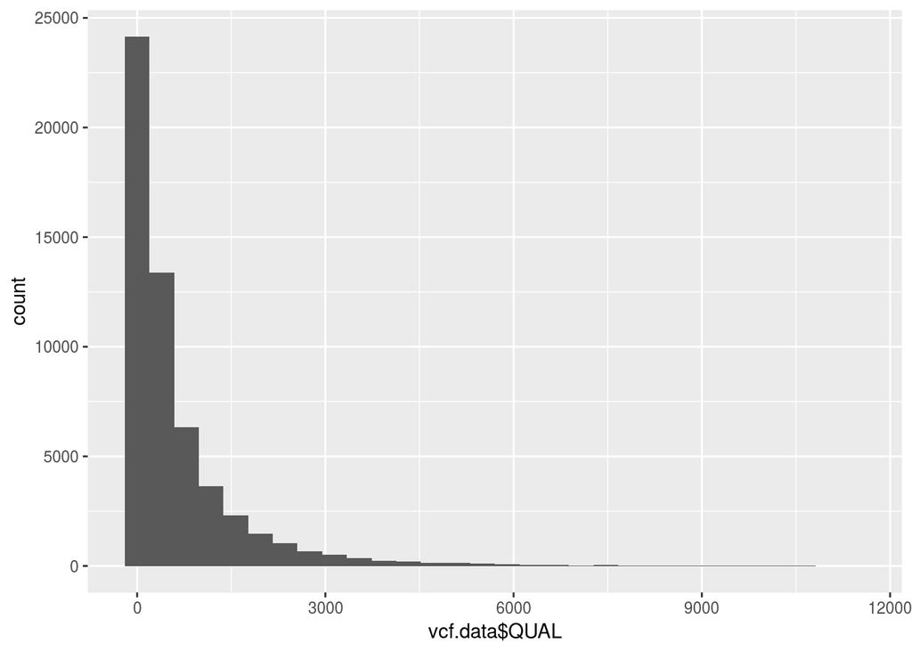

```r
ggplot(vcf.data, aes(x = vcf.data$QUAL)) + geom_histogram()
```

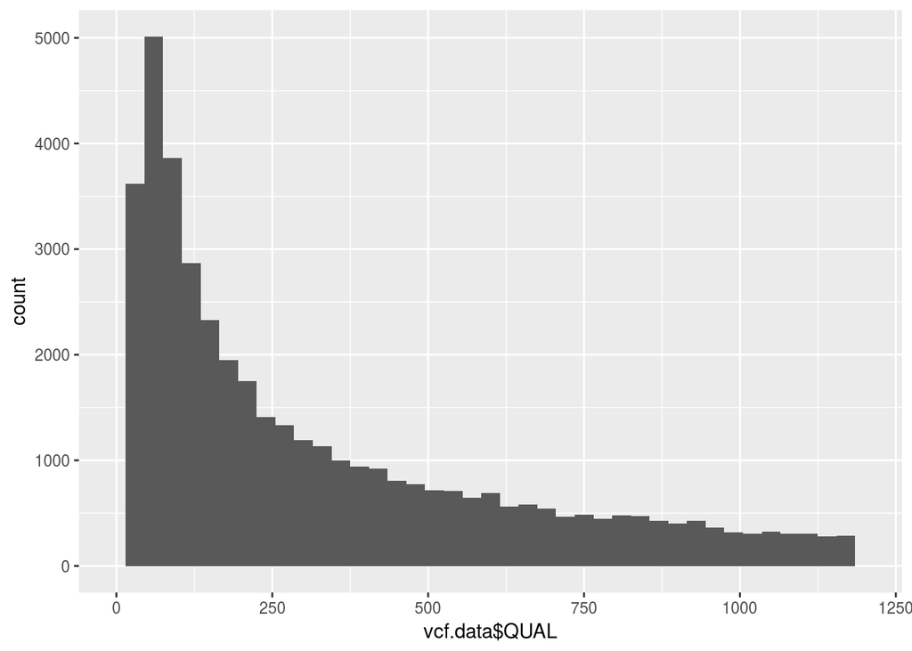

```r
#I defined the limits to QUAL value and adjusted the binwidth to focus on displaying the low QUAL scores in higher resolution.
#I am trying out different limits and binwidth to see what is most informative.
ggplot(vcf.data, aes(x = vcf.data$QUAL)) + geom_histogram(binwidth = 30) + xlim(0, 1200)
```

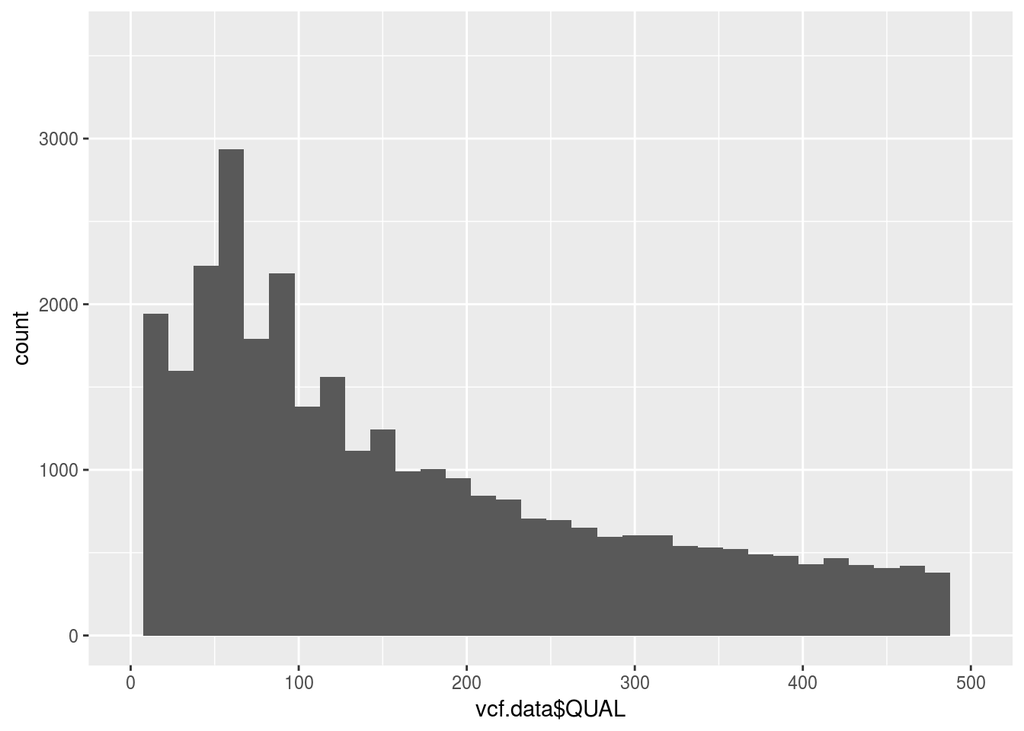

```r
ggplot(vcf.data, aes(x = vcf.data$QUAL)) + geom_histogram(binwidth = 15) + xlim(0, 500)
```

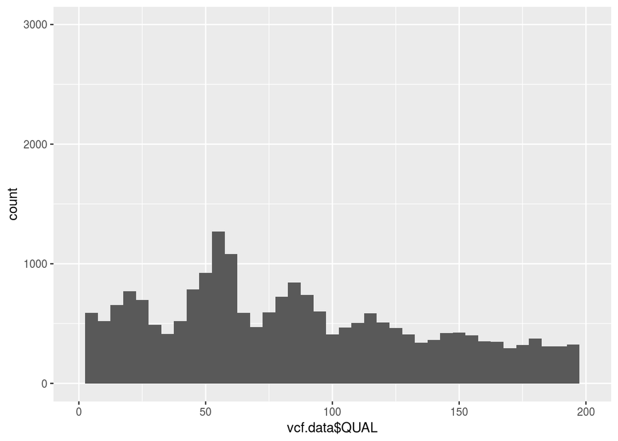

```r
ggplot(vcf.data, aes(x = vcf.data$QUAL)) + geom_histogram(binwidth = 5) + xlim(0, 200)
```

**Exercise 2**  
We only want to keep positions that have a reasonable probabilty of being correct.

**a** At a quality of 40 what is the probability that the SNP call is wrong?

> 10log_10prob(call in ALT is wrong) The probability the SNP call is wrong is .0001 or .01 %

**b** Subset the data to only keep positions where the quality score is 40 or greater.

```r
#subset SNPS with quality scores higher than 40
vcf.data.good <- subset(vcf.data, QUAL >= 40)
```

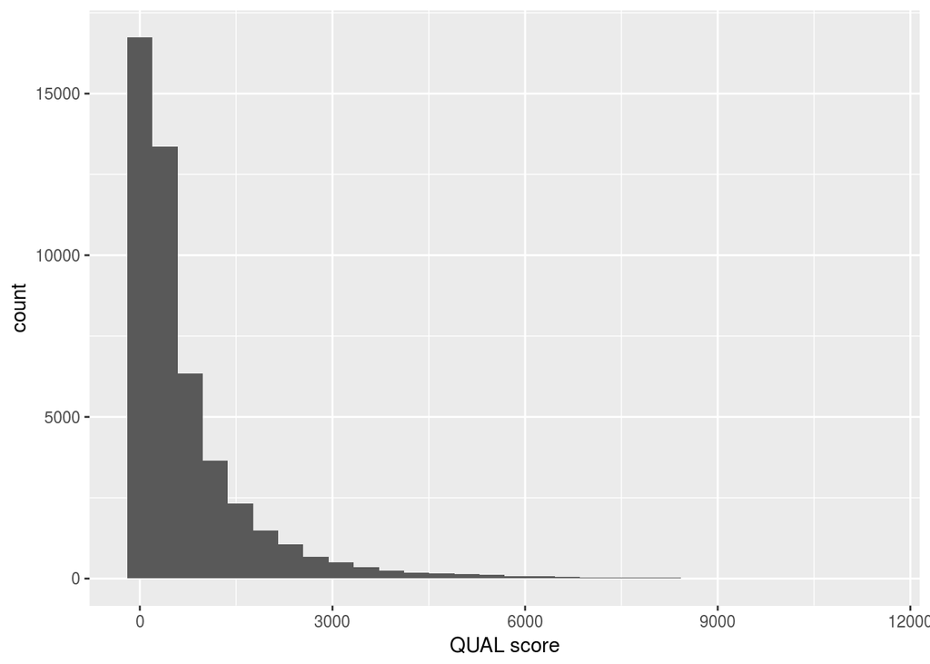

```r
#This is the new histogram representing SNPs of good quality.
ggplot(vcf.data.good, aes(x = vcf.data.good$QUAL)) + geom_histogram() + xlab("QUAL score")
```

**c** What percentage of SNPs were retained?

```r
#count the number of rows in the subsetted data
x <- nrow(vcf.data.good)

#Repeat for the original data set
y <- nrow(vcf.data)

#Calculate the percentage of SNPs retained
(x / y) * 100
```

```
## [1] 86.62141
```

> 86.62 percent of SNPs were retained.

We can count the number of homozygous and heterozygous SNPs using table

```r
table(vcf.data.good$IMB211_gt)
```

```
##
##   0/0   0/1   0/2   1/1   1/2   1/3   2/2   2/3   2/4   3/3    NA
##  9819  1682     8 31618   144     3   247     1     1     2  4193
```

```r
table(vcf.data.good$R500_gt)
```

```
##
##   0/0   0/1   0/2   1/1   1/2   1/3   2/2    NA
##  8028  1623    18 34255   150     3   247  3394
```

We can even count the numbers common and unique to each genotype

```r
#Table representing SNPs in the two cultivars.
ftable(vcf.data.good[,c("IMB211_gt","R500_gt")])
```

```
##           R500_gt   0/0   0/1   0/2   1/1   1/2   1/3   2/2    NA
## IMB211_gt
## 0/0                   1   402     0  9387    29     0     0     0
## 0/1                 348   736     5   434     7     0     6   146
## 0/2                   0     3     0     4     1     0     0     0
## 1/1                7659   362    12 20082    31     0   234  3238
## 1/2                  20     8     1    29    72     0     4    10
## 1/3                   0     0     0     0     0     0     3     0
## 2/2                   0     8     0   235     2     2     0     0
## 2/3                   0     1     0     0     0     0     0     0
## 2/4                   0     0     0     0     0     1     0     0
## 3/3                   0     0     0     0     2     0     0     0
## NA                    0   103     0  4084     6     0     0     0
```

**Exercise 3**  
**a** Which SNPS would be most useful for a downstream QTL analysis of F2 progeny generated from a cross of IMB211 and R500? (Ignore the allele categories that have “2”, “3”, or “4”). Hint: you want SNPs that will unambiguously distinguish a locus as coming from IMB211 or R500.

> QTL mapping surveys variation between 2 parents and attemps to find if a loci is associated with a certain phenotype. SNPs that are either 0/0 or 1/1 will be useful for QTL analysis for crossing IMB211 and R500. For generating the cross, one of the parents will have to be 0/0 (homozygous and similar to the reference genome) and the other parent will have to be 1/1 (homozygous and different from the reference genome). This will allow us to obtain homozygous alternate and a homozygous wt in our F2 progeny.

**b** Subset the data frame so that you only have these SNPs.

```r
summary(vcf.data.good)
```

```
##     CHROM                POS              ID              REF
##  Length:47718       Min.   :    4862   Mode:logical   Length:47718
##  Class :character   1st Qu.: 4671073   NA's:47718     Class :character
##  Mode  :character   Median :10643649                  Mode  :character
##                     Mean   :12586842
##                     3rd Qu.:21317708
##                     Max.   :26784033
##
##      ALT                 QUAL          FILTER            INFO
##  Length:47718       Min.   :   40.0   Mode:logical   Length:47718
##  Class :character   1st Qu.:  128.3   NA's:47718     Class :character
##  Mode  :character   Median :  355.5                  Mode  :character
##                     Mean   :  752.2
##                     3rd Qu.:  928.0
##                     Max.   :11404.7
##
##     FORMAT             IMB211              R500
##  Length:47718       Length:47718       Length:47718
##  Class :character   Class :character   Class :character
##  Mode  :character   Mode  :character   Mode  :character
##
##
##
##
##   IMB211_gt         IMB211_tot.depth IMB211_ref.depth  IMB211_ref.qual
##  Length:47718       Min.   :  1.0    Min.   :  0.000   Min.   :   0.0
##  Class :character   1st Qu.:  4.0    1st Qu.:  0.000   1st Qu.:   0.0
##  Mode  :character   Median : 11.0    Median :  0.000   Median :   0.0
##                     Mean   : 18.7    Mean   :  5.358   Mean   : 194.4
##                     3rd Qu.: 24.0    3rd Qu.:  1.000   3rd Qu.:  41.0
##                     Max.   :182.0    Max.   :173.000   Max.   :6511.0
##                     NA's   :4193     NA's   :4193      NA's   :4193
##  IMB211_alt.depth IMB211_alt.qual  IMB211_gen.lik       R500_gt
##  Min.   :  0.00   Min.   :   0.0   Length:47718       Length:47718
##  1st Qu.:  1.00   1st Qu.:  38.0   Class :character   Class :character
##  Median :  6.00   Median : 198.0   Mode  :character   Mode  :character
##  Mean   : 13.14   Mean   : 474.9
##  3rd Qu.: 17.00   3rd Qu.: 615.0
##  Max.   :182.00   Max.   :6944.0
##  NA's   :4923     NA's   :4923
##  R500_tot.depth   R500_ref.depth    R500_ref.qual    R500_alt.depth
##  Min.   :  1.00   Min.   :  0.000   Min.   :   0.0   Min.   :  0.00
##  1st Qu.:  5.00   1st Qu.:  0.000   1st Qu.:   0.0   1st Qu.:  2.00
##  Median : 11.00   Median :  0.000   Median :   0.0   Median :  7.00
##  Mean   : 19.32   Mean   :  4.555   Mean   : 165.3   Mean   : 14.58
##  3rd Qu.: 25.00   3rd Qu.:  0.000   3rd Qu.:   0.0   3rd Qu.: 19.00
##  Max.   :186.00   Max.   :184.000   Max.   :6930.0   Max.   :185.00
##  NA's   :3394     NA's   :3394      NA's   :3394     NA's   :4120
##  R500_alt.qual    R500_gen.lik
##  Min.   :   0.0   Length:47718
##  1st Qu.:  72.0   Class :character
##  Median : 242.0   Mode  :character
##  Mean   : 527.4
##  3rd Qu.: 697.0
##  Max.   :7017.0
##  NA's   :4120
```

```r
vcf.data.QTL <- subset(vcf.data.good, (vcf.data.good$IMB211_gt == "1/1" & vcf.data.good$R500_gt == "0/0") | (vcf.data.good$IMB211_gt == "0/0" & vcf.data.good$R500_gt == "1/1"))

summary(vcf.data.QTL)
```

```
##     CHROM                POS              ID              REF
##  Length:17046       Min.   :  159994   Mode:logical   Length:17046
##  Class :character   1st Qu.: 6786771   NA's:17046     Class :character
##  Mode  :character   Median :12279912                  Mode  :character
##                     Mean   :14110531
##                     3rd Qu.:22290049
##                     Max.   :26776300
##      ALT                 QUAL          FILTER            INFO
##  Length:17046       Min.   :  40.03   Mode:logical   Length:17046
##  Class :character   1st Qu.: 144.16   NA's:17046     Class :character
##  Mode  :character   Median : 352.04                  Mode  :character
##                     Mean   : 589.91
##                     3rd Qu.: 779.16
##                     Max.   :6093.83
##     FORMAT             IMB211              R500
##  Length:17046       Length:17046       Length:17046
##  Class :character   Class :character   Class :character
##  Mode  :character   Mode  :character   Mode  :character
##
##
##
##   IMB211_gt         IMB211_tot.depth IMB211_ref.depth IMB211_ref.qual
##  Length:17046       Min.   :  1.0    Min.   :  0.00   Min.   :   0.0
##  Class :character   1st Qu.:  6.0    1st Qu.:  0.00   1st Qu.:   0.0
##  Mode  :character   Median : 14.0    Median :  2.00   Median :  76.0
##                     Mean   : 21.4    Mean   : 11.88   Mean   : 431.1
##                     3rd Qu.: 28.0    3rd Qu.: 16.00   3rd Qu.: 578.0
##                     Max.   :174.0    Max.   :173.00   Max.   :6511.0
##  IMB211_alt.depth  IMB211_alt.qual  IMB211_gen.lik       R500_gt
##  Min.   :  0.000   Min.   :   0.0   Length:17046       Length:17046
##  1st Qu.:  0.000   1st Qu.:   0.0   Class :character   Class :character
##  Median :  0.000   Median :   0.0   Mode  :character   Mode  :character
##  Mean   :  9.357   Mean   : 338.5
##  3rd Qu.: 11.000   3rd Qu.: 399.0
##  Max.   :171.000   Max.   :6388.0
##  R500_tot.depth   R500_ref.depth    R500_ref.qual    R500_alt.depth
##  Min.   :  1.00   Min.   :  0.000   Min.   :   0.0   Min.   :  0.00
##  1st Qu.:  7.00   1st Qu.:  0.000   1st Qu.:   0.0   1st Qu.:  0.00
##  Median : 14.00   Median :  0.000   Median :   0.0   Median :  4.00
##  Mean   : 21.89   Mean   :  9.958   Mean   : 361.5   Mean   : 11.77
##  3rd Qu.: 29.00   3rd Qu.: 12.000   3rd Qu.: 445.0   3rd Qu.: 16.00
##  Max.   :186.00   Max.   :184.000   Max.   :6930.0   Max.   :185.00
##  R500_alt.qual    R500_gen.lik
##  Min.   :   0.0   Length:17046
##  1st Qu.:   0.0   Class :character
##  Median : 146.0   Mode  :character
##  Mean   : 425.8
##  3rd Qu.: 584.0
##  Max.   :7017.0
```

**c** How many SNPs are retained?

```r
#Calculate the percent of SNPs that were retained
a <- nrow(vcf.data.QTL)
b <- nrow(vcf.data.good)

a
```

```
## [1] 17046
```

```r
(a / b) * 100
```

```
## [1] 35.72237
```

> 17046 SNPs were retained. That is 35.72% of the original SNPs contained in vcf.data.good.

**Exercise 4**  
**a** Using the higher quality SNP list, plot the position along the chromosome of each SNP (x axis), read depth (R500 and IMB211 combined) (y axis). Optional: color each SNP for whether it is R500 specific, IMB specific, or common.

```r
library(reshape2)
data1 <- vcf.data.good[,c("IMB211_tot.depth", "POS", "R500_tot.depth")]
data1.melt <- melt(data1, id.var="POS")
```

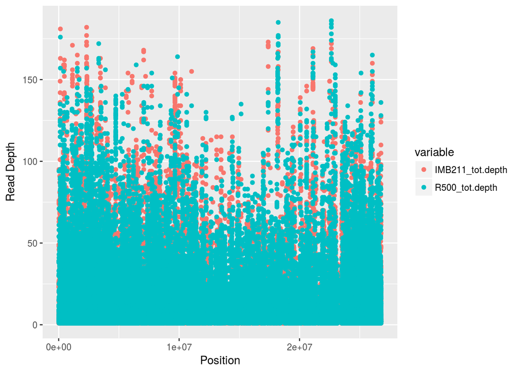

```r
ggplot(data1.melt, aes(x = POS, y = value, color = variable)) + geom_point() + xlab("Position") + ylab("Read Depth")
```

**b** Use the help function to learn about xlim(). Use this function to plot only the region betweeen 20,000,000 and 25,000,000 bp. Why might there be gaps with no SNPs?

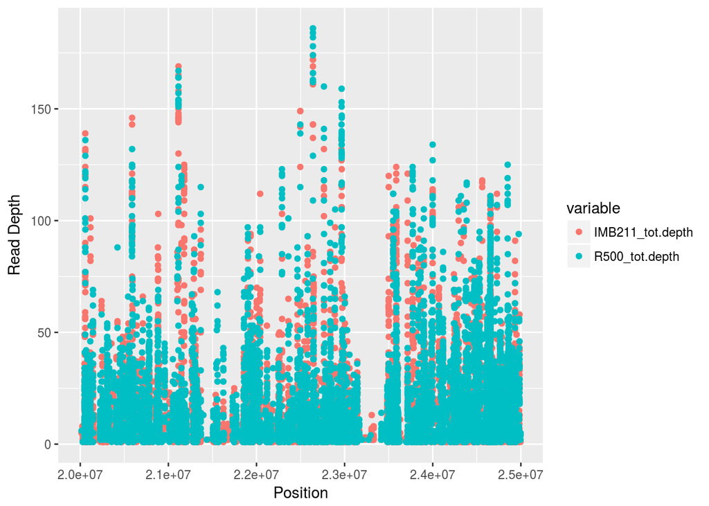

```r
ggplot(data1.melt, aes(x = POS, y = value, color = variable)) + geom_point() + xlim(20000000, 25000000) + xlab("Position") + ylab("Read Depth")
```

For Fun (?)–not graded– Plot the number of each type of base change (A->G, etc). Are there differences? Is this expected?